# Real Estate Property Price Prediction & Investment Insights Analysis

```python
%matplotlib inline
import numpy as np
import pandas as pd
import matplotlib.pyplot as plt
import seaborn as sns
```

```python
df = pd.read_csv(r"C:\Users\DEEP PC\Desktop\New folder (3)\train.csv")
```

```python
df.head()
```

|  | Id | MSSubClass | MSZoning | LotFrontage | LotArea | Street | Alley | LotShape | LandContour | Utilities | ... | PoolArea | PoolQC | Fence | MiscFeature | MiscVal | MoSold | YrSold | SaleType | SaleCondition | SalePrice |
| --- | --- | --- | --- | --- | --- | --- | --- | --- | --- | --- | --- | --- | --- | --- | --- | --- | --- | --- | --- | --- | --- |
| 0 | 1 | 60 | RL | 65.0 | 8450 | Pave | NaN | Reg | Lvl | AllPub | ... | 0 | NaN | NaN | NaN | 0 | 2 | 2008 | WD | Normal | 208500 |
| 1 | 2 | 20 | RL | 80.0 | 9600 | Pave | NaN | Reg | Lvl | AllPub | ... | 0 | NaN | NaN | NaN | 0 | 5 | 2007 | WD | Normal | 181500 |
| 2 | 3 | 60 | RL | 68.0 | 11250 | Pave | NaN | IR1 | Lvl | AllPub | ... | 0 | NaN | NaN | NaN | 0 | 9 | 2008 | WD | Normal | 223500 |
| 3 | 4 | 70 | RL | 60.0 | 9550 | Pave | NaN | IR1 | Lvl | AllPub | ... | 0 | NaN | NaN | NaN | 0 | 2 | 2006 | WD | Abnorml | 140000 |
| 4 | 5 | 60 | RL | 84.0 | 14260 | Pave | NaN | IR1 | Lvl | AllPub | ... | 0 | NaN | NaN | NaN | 0 | 12 | 2008 | WD | Normal | 250000 |

5 rows × 81 columns

```python
df.columns
```

```
Index(['Id', 'MSSubClass', 'MSZoning', 'LotFrontage', 'LotArea', 'Street',
       'Alley', 'LotShape', 'LandContour', 'Utilities', 'LotConfig',
       'LandSlope', 'Neighborhood', 'Condition1', 'Condition2', 'BldgType',
       'HouseStyle', 'OverallQual', 'OverallCond', 'YearBuilt', 'YearRemodAdd',
       'RoofStyle', 'RoofMatl', 'Exterior1st', 'Exterior2nd', 'MasVnrType',
       'MasVnrArea', 'ExterQual', 'ExterCond', 'Foundation', 'BsmtQual',
       'BsmtCond', 'BsmtExposure', 'BsmtFinType1', 'BsmtFinSF1',
       'BsmtFinType2', 'BsmtFinSF2', 'BsmtUnfSF', 'TotalBsmtSF', 'Heating',
       'HeatingQC', 'CentralAir', 'Electrical', '1stFlrSF', '2ndFlrSF',
       'LowQualFinSF', 'GrLivArea', 'BsmtFullBath', 'BsmtHalfBath', 'FullBath',
       'HalfBath', 'BedroomAbvGr', 'KitchenAbvGr', 'KitchenQual',
       'TotRmsAbvGrd', 'Functional', 'Fireplaces', 'FireplaceQu', 'GarageType',
       'GarageYrBlt', 'GarageFinish', 'GarageCars', 'GarageArea', 'GarageQual',
       'GarageCond', 'PavedDrive', 'WoodDeckSF', 'OpenPorchSF',
       'EnclosedPorch', '3SsnPorch', 'ScreenPorch', 'PoolArea', 'PoolQC',
       'Fence', 'MiscFeature', 'MiscVal', 'MoSold', 'YrSold', 'SaleType',
       'SaleCondition', 'SalePrice'],
      dtype='object')
```

```python
df.shape
```

```
(1460, 81)
```

## The dataset consists of 1460 records and multiple features. Some variables are numerical while others are categorical. A few columns contain missing values, which will be handled in the data cleaning phase.

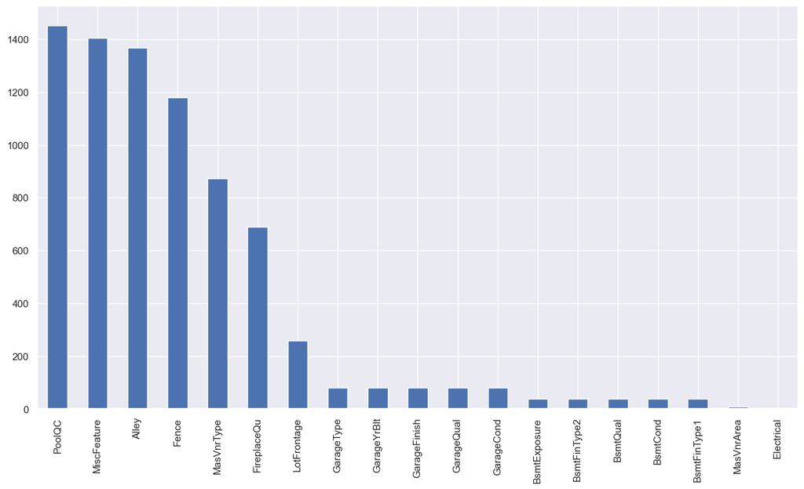

```python
missing = df.isnull().sum()
missing = missing[missing > 0]
missing = missing.sort_values(ascending=False)
plt.figure(figsize=(15,8))
missing.plot.bar()
```

## Several features contain missing values. Some columns like PoolQC, MiscFeature, and Alley have a high percentage of missing data, indicating they may not be useful for analysis and can be removed.

```python
df['SalePrice'].describe()
```

```
count      1460.000000
mean     180921.195890
std       79442.502883
min       34900.000000
25%      129975.000000
50%      163000.000000
75%      214000.000000
max      755000.000000
Name: SalePrice, dtype: float64
```

[output not shown]

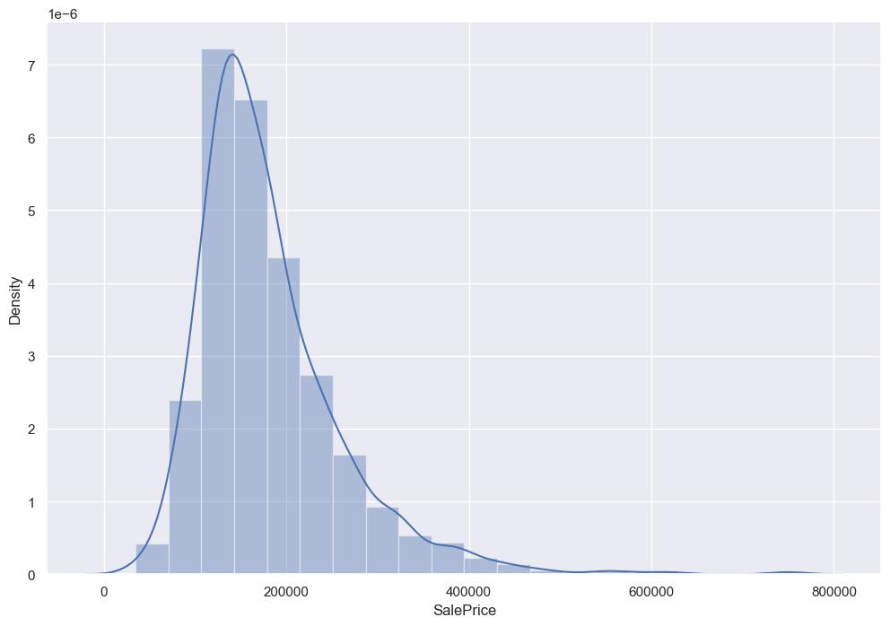

```python
sns.set(rc={'figure.figsize':(12,8)})

sns.distplot(df['SalePrice'],  bins=20)
```

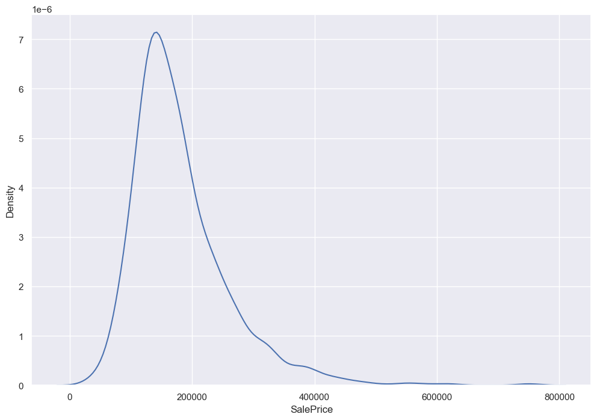

```python
sns.kdeplot(df['SalePrice'])
```

```python
df['SalePrice'].describe()
```

```
count      1460.000000
mean     180921.195890
std       79442.502883
min       34900.000000
25%      129975.000000
50%      163000.000000
75%      214000.000000
max      755000.000000
Name: SalePrice, dtype: float64
```

## The target variable (SalePrice) shows a right-skewed distribution, indicating the presence of high-value outliers. This suggests the need for transformation such as log scaling for better modeling.

```python
# Separate numeric features
numeric_features = df.select_dtypes(include=[np.number])
numeric_features.columns
```

```
Index(['Id', 'MSSubClass', 'LotFrontage', 'LotArea', 'OverallQual',
       'OverallCond', 'YearBuilt', 'YearRemodAdd', 'MasVnrArea', 'BsmtFinSF1',
       'BsmtFinSF2', 'BsmtUnfSF', 'TotalBsmtSF', '1stFlrSF', '2ndFlrSF',
       'LowQualFinSF', 'GrLivArea', 'BsmtFullBath', 'BsmtHalfBath', 'FullBath',
       'HalfBath', 'BedroomAbvGr', 'KitchenAbvGr', 'TotRmsAbvGrd',
       'Fireplaces', 'GarageYrBlt', 'GarageCars', 'GarageArea', 'WoodDeckSF',
       'OpenPorchSF', 'EnclosedPorch', '3SsnPorch', 'ScreenPorch', 'PoolArea',
       'MiscVal', 'MoSold', 'YrSold', 'SalePrice'],
      dtype='object')
```

```python
# Correlation matrix
correlation = numeric_features.corr()
print(correlation['SalePrice'].sort_values(ascending=False), '\n')
```

```
SalePrice        1.000000
OverallQual      0.790982
GrLivArea        0.708624
GarageCars       0.640409
GarageArea       0.623431
TotalBsmtSF      0.613581
1stFlrSF         0.605852
FullBath         0.560664
TotRmsAbvGrd     0.533723
YearBuilt        0.522897
YearRemodAdd     0.507101
GarageYrBlt      0.486362
MasVnrArea       0.477493
Fireplaces       0.466929
BsmtFinSF1       0.386420
LotFrontage      0.351799
WoodDeckSF       0.324413
2ndFlrSF         0.319334
OpenPorchSF      0.315856
HalfBath         0.284108
LotArea          0.263843
BsmtFullBath     0.227122
BsmtUnfSF        0.214479
BedroomAbvGr     0.168213
ScreenPorch      0.111447
PoolArea         0.092404
MoSold           0.046432
3SsnPorch        0.044584
BsmtFinSF2      -0.011378
BsmtHalfBath    -0.016844
MiscVal         -0.021190
Id              -0.021917
LowQualFinSF    -0.025606
YrSold          -0.028923
OverallCond     -0.077856
MSSubClass      -0.084284
EnclosedPorch   -0.128578
KitchenAbvGr    -0.135907
Name: SalePrice, dtype: float64
```

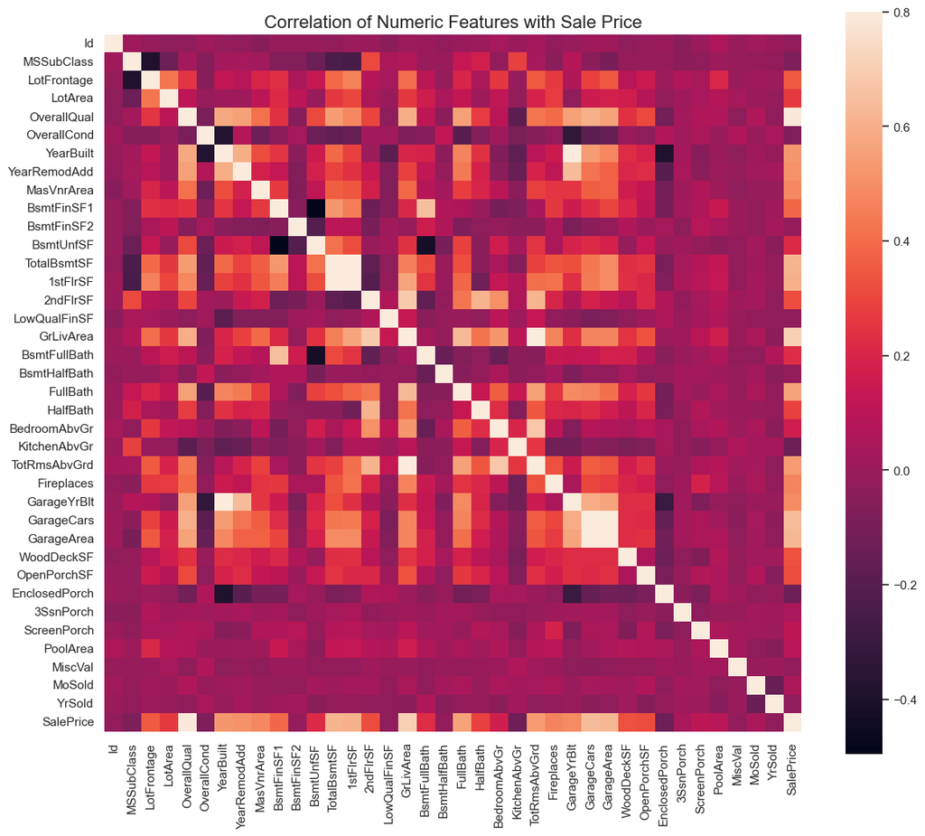

```python
# Full heatmap
f, ax = plt.subplots(figsize=(14,12))
plt.title('Correlation of Numeric Features with Sale Price', y=1, size=16)
sns.heatmap(correlation, square=True, vmax=0.8)
```

```
Index(['SalePrice', 'OverallQual', 'GrLivArea', 'GarageCars', 'GarageArea',
       'TotalBsmtSF', '1stFlrSF', 'FullBath', 'TotRmsAbvGrd', 'YearBuilt',
       'YearRemodAdd'],
      dtype='object')
```

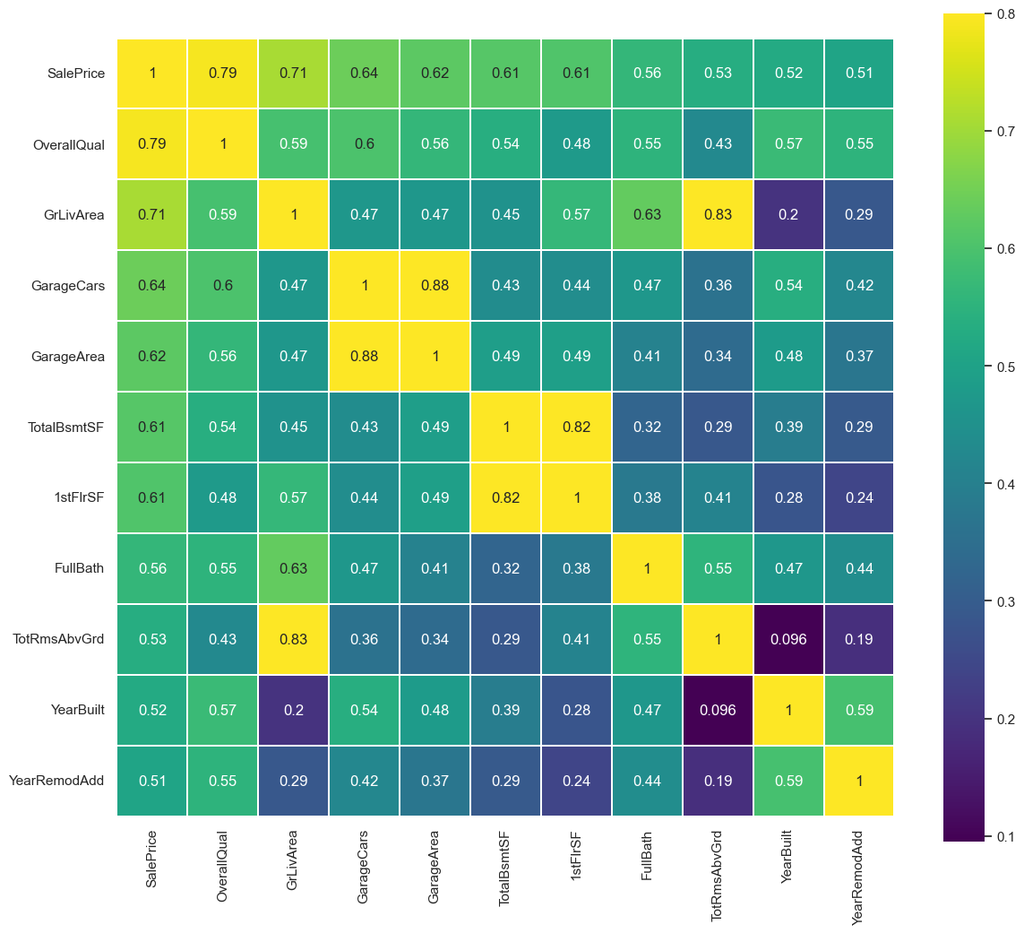

```python
# Top correlated features
k = 11
cols = correlation.nlargest(k, 'SalePrice')['SalePrice'].index
print(cols)

cm = np.corrcoef(df[cols].values.T)

f, ax = plt.subplots(figsize=(14,12))
sns.heatmap(cm, vmax=0.8, linewidths=0.01, square=True,
            annot=True, cmap='viridis',
            linecolor="white",
            xticklabels=cols.values,
            yticklabels=cols.values,
            annot_kws={'size':12})
```

## The heatmap highlights the correlation between key numerical features and SalePrice.

It is observed that OverallQual (0.79) and GrLivArea (0.71) have the strongest positive correlation with SalePrice, indicating that property quality and living area are the most significant drivers of property valuation.

Garage-related features such as GarageCars (0.64) and GarageArea (0.62) also show strong correlation, suggesting that parking capacity and space add substantial value to properties.

Additionally, TotalBsmtSF and 1stFlrSF demonstrate moderate positive relationships, indicating that total usable area contributes to price.

However, strong correlation is also observed between some independent variables themselves, such as:

- GarageCars and GarageArea (0.88)
- GrLivArea and TotRmsAbvGrd

This indicates multicollinearity, meaning some features provide redundant information. These features will be carefully handled or removed in the feature selection stage to improve model performance.

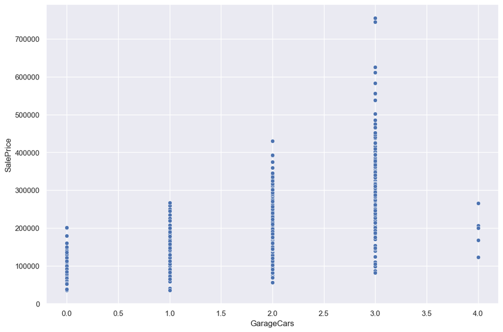

```python
sns.scatterplot(x='GarageCars', y='SalePrice', data=df)
```

## The scatter plot shows a positive relationship between garage capacity and sale price, indicating that properties with more parking space tend to have higher value.

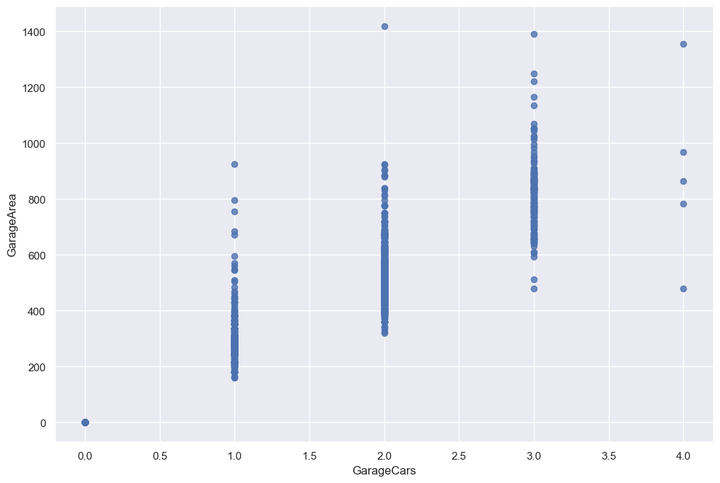

```python
sns.regplot(x='GarageCars', y='GarageArea', data=df, scatter=True, fit_reg=False)
```

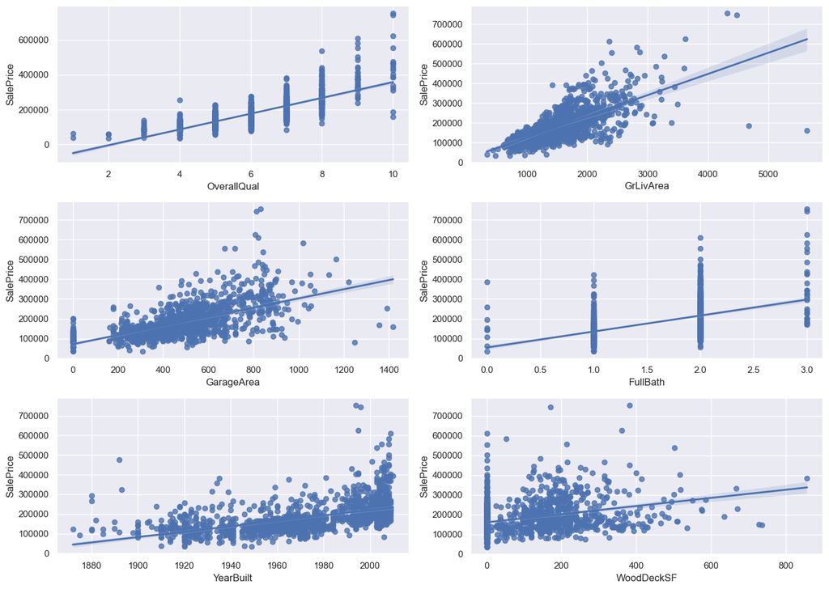

```python
# scatter plots between the most correlated variables

import matplotlib.pyplot as plt

fig, ((ax1, ax2), (ax3, ax4), (ax5, ax6)) = plt.subplots(nrows=3, ncols=2, figsize=(14,10))

sns.regplot(x='OverallQual', y='SalePrice', data=df, scatter=True, fit_reg=True, ax=ax1)

sns.regplot(x='GrLivArea', y='SalePrice', data=df, scatter=True, fit_reg=True, ax=ax2)

sns.regplot(x='GarageArea', y='SalePrice', data=df, scatter=True, fit_reg=True, ax=ax3)

sns.regplot(x='FullBath', y='SalePrice', data=df, scatter=True, fit_reg=True, ax=ax4)

sns.regplot(x='YearBuilt', y='SalePrice', data=df, scatter=True, fit_reg=True, ax=ax5)

sns.regplot(x='WoodDeckSF', y='SalePrice', data=df, scatter=True, fit_reg=True, ax=ax6)

plt.tight_layout()
plt.show()
```

# The scatter plots illustrate the relationship between key features and SalePrice.

A strong positive linear relationship is observed between OverallQual and SalePrice, indicating that higher-quality properties command significantly higher prices.

Similarly, GrLivArea shows a clear upward trend, confirming that larger living areas lead to higher property valuation. This is one of the most important predictors of price.

GarageArea also shows a positive relationship with SalePrice, suggesting that larger garage space contributes to property value, although with slightly more variability.

FullBath demonstrates a moderate positive impact, indicating that properties with more bathrooms tend to be priced higher.

YearBuilt shows a mild positive trend, implying that newer properties generally have higher prices, but the relationship is not as strong as size or quality.

WoodDeckSF has a weaker and more scattered relationship, suggesting that outdoor deck space has limited influence on property pricing.

Overall, these plots confirm that structural and quality-related features have the strongest influence on house prices, while secondary amenities contribute less significantly.

# These insights validate the correlation analysis and will help prioritize the most impactful features for predictive modeling.

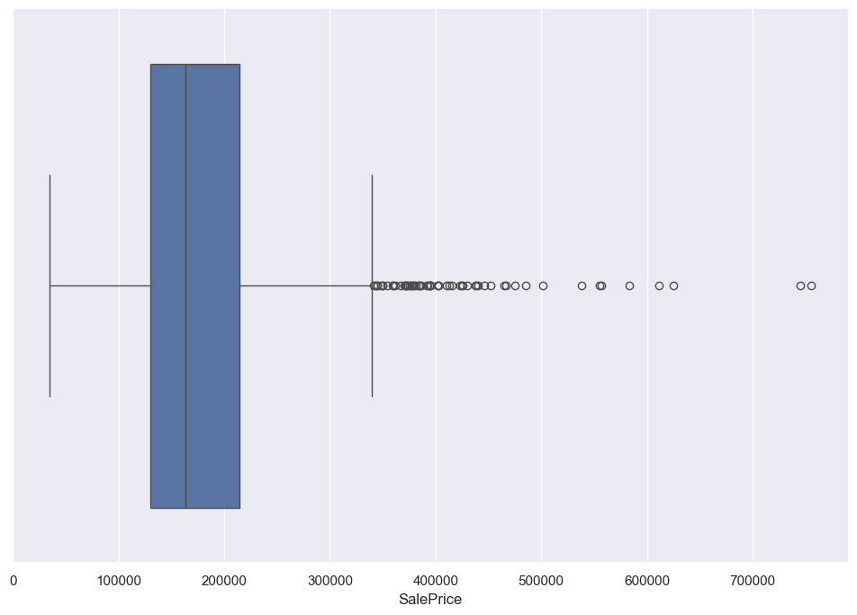

```python
sns.boxplot(x=df["SalePrice"])
```

## The boxplot reveals the presence of outliers in the SalePrice variable. These extreme values can distort analysis and will be handled using the IQR method.

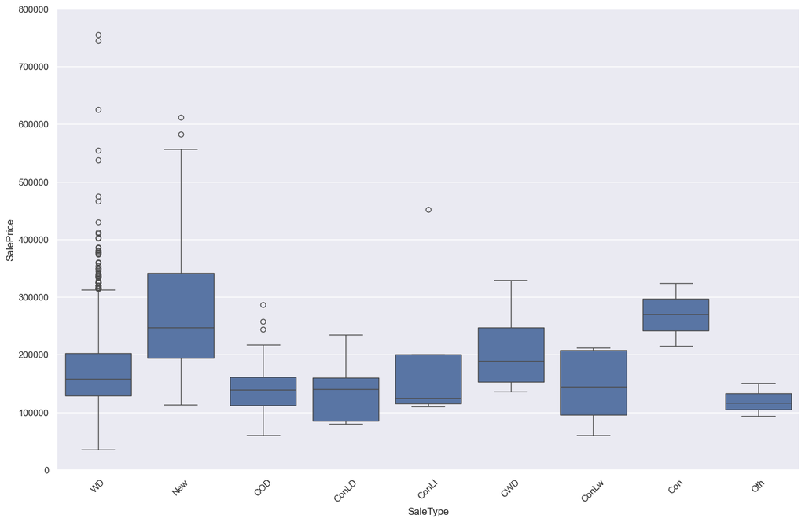

```python
f, ax = plt.subplots(figsize=(16, 10))

fig = sns.boxplot(x='SaleType', y='SalePrice', data=df)

fig.axis(ymin=0, ymax=800000)

xt = plt.xticks(rotation=45)
```

## The boxplot illustrates the distribution of SalePrice across different SaleType categories.

It is observed that certain sale types, such as New and Con (Contract sales), tend to have higher median prices, indicating that newly constructed or directly contracted properties are generally more expensive.

On the other hand, sale types like WD (Warranty Deed), which represent standard resale transactions, show a wider spread and lower median prices, suggesting higher variability in resale property values.

The presence of multiple outliers across categories indicates that some properties are priced significantly higher than typical market values. These extreme values can distort analysis and will be addressed using outlier treatment methods.

Overall, the type of sale has a noticeable impact on property pricing and reflects different market segments within the real estate domain.

# This insight helps in understanding how transaction type influences pricing and can be useful for market segmentation.

```
(np.float64(-0.5), np.float64(9.5), np.float64(0.0), np.float64(800000.0))
```

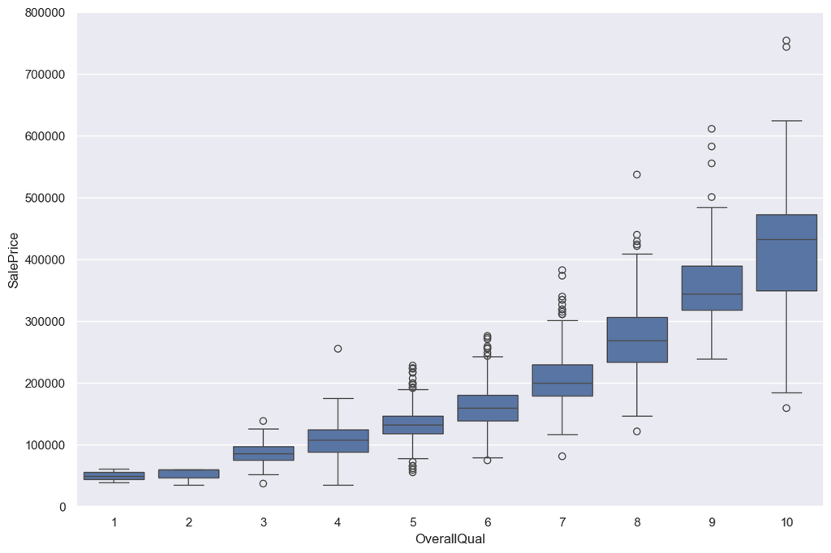

```python
f, ax = plt.subplots(figsize=(12, 8))

fig = sns.boxplot(x='OverallQual', y='SalePrice', data=df)

fig.axis(ymin=0, ymax=800000)
```

## The boxplot clearly demonstrates the relationship between OverallQual (overall material and finish quality) and SalePrice.

A strong upward trend is observed, where higher quality ratings consistently correspond to higher property prices. Properties with low quality ratings (1–3) have significantly lower median prices, while properties with high ratings (8–10) show a substantial increase in price.

The spread of prices also increases with higher quality levels, indicating greater variability in premium properties. This suggests that high-end properties can vary widely in pricing based on additional features.

Although some outliers are present across different quality levels, the overall pattern confirms that OverallQual is one of the most influential factors in determining property value.

This makes OverallQual a critical feature for predictive modeling and real estate valuation.